# Negative Binomial Regression Fit Report

20250610

## Project Summary

- We are using data from the American Society of Microbiology’s (ASM) 12 published journals to investigate the relationship between the number of citations (variable ‘is.referenced.by.count’) a published scientific article receives and if the authors have included access to their raw sequencing data (variable ‘da’, data availability) in the manuscript.
- We are trying to understand if publishing raw data helps to improve citation metrics. We have data from 2000-2024, and will also adjust for time published (variable ‘age.in.months’), as older papers have had the opportunity to accumulate more citations over time.

## Negative Binomial Model Formats

- Model format for all data from all journals:
  - MASS::glm.nb(is.referenced.by.count~ da_factor + log(age.in.months) + container.title + container.title*da_factor + log(age.in.months)*da_factor + container.title*log(age.in.months) + log(age.in.months)*da_factor*container.title, data = nsd_yes_metadata, link = log)
- Use model format for data from each journal:
  - MASS::glm.nb(is.referenced.by.count~ da_factor + log(age.in.months) + log(age.in.months)*da_factor, data = <each journal>, link = log)
  - Data with N > 10 to create model
- Model names
  - “full” - model created with no data removed
  - “time adj” - model adjusted for avg age of 1st citation in dataset (age.in.months = 5)
  - “at one year” – model created with only age.in.months == 12
  - “at five years” – model created with only age.in.months == 60
  - “five years” – model created with only age.in.months between 0 and 60
  - “at ten years” – model created with only age.in.months == 120
  - “ten years” – model created with only age.in.months between 0 and 120
  - “journal” - model created for each journal individually, N > 10 per condition

| coefficients | full | full pvalue | time adj | time adj pvalue | at one year | at one year pvalue | at five years | at five years pvalue | five years | five years pvalue | at ten years | at ten years pvalue | ten years | ten years pvalue | pretty name |
| --- | --- | --- | --- | --- | --- | --- | --- | --- | --- | --- | --- | --- | --- | --- | --- |
| rsquared | 0.678 |  | 0.681 |  | 0.355 |  | 0.516 |  | 0.660 |  | 0.223 |  | 0.680 |  | rsquared |
| (Intercept) | -0.946 | 0.000 | -0.580 | 0.000 | -2.334 | 0.100 | 2.539 | 0.000 | -3.473 | 0.000 | 3.995 | 0.000 | -2.696 | 0.000 | (Intercept) |
| da_factorYes | -1.508 | 0.000 | -0.972 | 0.000 | 1.929 | 0.089 | 0.258 | 0.628 | -0.178 | 0.763 | -0.075 | 0.840 | -0.267 | 0.448 | da_Yes |
| log(age.in.months) | 0.993 | 0.000 | 0.928 | 0.000 |  |  |  |  | 1.614 | 0.000 |  |  | 1.398 | 0.000 | log(time) |
| container.titleApplied and Environmental Microbiology | -1.034 | 0.000 | -0.885 | 0.000 | 2.334 | 0.166 | 0.198 | 0.685 | -0.121 | 0.828 | 0.046 | 0.866 | -0.565 | 0.079 | aem |
| container.titleGenome Announcements | -4.530 | 0.002 | -4.495 | 0.001 |  |  |  |  |  |  |  |  | -8.881 | 0.001 | genomea |
| container.titleInfection and Immunity | -0.793 | 0.002 | -0.795 | 0.001 | -13.968 | 0.995 | 0.234 | 0.780 | -1.329 | 0.168 | -0.337 | 0.399 | -1.180 | 0.024 | iai |
| container.titleJournal of Bacteriology | -1.171 | 0.000 | -1.077 | 0.000 | 2.894 | 0.057 | -0.460 | 0.453 | -0.336 | 0.635 | -0.344 | 0.390 | -0.250 | 0.552 | jb |
| container.titleJournal of Clinical Microbiology | 0.273 | 0.196 | 0.222 | 0.261 | 3.433 | 0.048 | -0.188 | 0.782 | -0.678 | 0.353 | -0.846 | 0.001 | 1.976 | 0.000 | jcm |
| container.titleJournal of Microbiology & Biology Education | -0.226 | 0.900 | -0.221 | 0.863 |  |  |  |  | 1.022 | 0.701 |  |  | 1.542 | 0.385 | jmbe |
| container.titleJournal of Virology | -0.437 | 0.013 | -0.355 | 0.030 | 2.922 | 0.052 | -0.033 | 0.946 | -0.173 | 0.755 | -0.061 | 0.826 | 0.201 | 0.526 | jvi |
| container.titlemBio | -1.882 | 0.000 | -1.114 | 0.000 | 4.819 | 0.001 |  |  | 0.012 | 0.983 |  |  | -0.266 | 0.402 | mbio |
| container.titleMicrobiology Resource Announcements | -3.084 | 0.029 | -2.174 | 0.055 | -1.215 | 0.170 | -1.557 | 0.000 | -0.017 | 0.992 |  |  | -1.325 | 0.347 | mra |
| container.titleMicrobiology Spectrum | -3.555 | 0.000 | -1.706 | 0.000 | 2.359 | 0.100 |  |  | -1.002 | 0.059 |  |  | -1.791 | 0.000 | spectrum |
| container.titlemSphere | -2.577 | 0.000 | -1.512 | 0.000 | 2.334 | 0.127 |  |  | -0.222 | 0.727 |  |  | -0.827 | 0.049 | msphere |
| container.titlemSystems | -2.629 | 0.000 | -1.281 | 0.000 | 1.236 | 0.164 |  |  | -0.029 | 0.964 |  |  | -0.870 | 0.053 | msystems |
| da_factorYes:container.titleApplied and Environmental Microbiology | 0.869 | 0.002 | 0.744 | 0.003 | -1.592 | 0.290 | 0.154 | 0.800 | -0.191 | 0.783 | 0.269 | 0.548 | 0.100 | 0.811 | da_Yes:aem |
| da_factorYes:container.titleGenome Announcements | 1.688 | 0.259 | 1.168 | 0.407 |  |  |  |  |  |  |  |  | 7.219 | 0.011 | da_Yes:genomea |
| da_factorYes:container.titleInfection and Immunity | 1.085 | 0.011 | 0.890 | 0.023 | 15.067 | 0.994 | -1.239 | 0.301 | 0.964 | 0.430 |  |  | 0.860 | 0.221 | da_Yes:iai |
| da_factorYes:container.titleJournal of Bacteriology | 1.526 | 0.000 | 1.118 | 0.001 | -0.697 | 0.655 | 1.074 | 0.180 | 0.885 | 0.358 |  |  | 0.205 | 0.737 | da_Yes:jb |
| da_factorYes:container.titleJournal of Clinical Microbiology | 0.799 | 0.027 | 0.709 | 0.030 | -2.111 | 0.209 | -0.045 | 0.966 | 1.110 | 0.232 | 0.360 | 0.521 | -1.634 | 0.002 | da_Yes:jcm |
| da_factorYes:container.titleJournal of Microbiology & Biology Education |  |  |  |  |  |  |  |  |  |  |  |  |  |  | da_Yes:jmbe |
| da_factorYes:container.titleJournal of Virology | 0.802 | 0.009 | 0.630 | 0.023 | -1.669 | 0.226 | -0.428 | 0.521 | -0.086 | 0.907 | 0.155 | 0.784 | -0.347 | 0.440 | da_Yes:jvi |
| da_factorYes:container.titlemBio | 1.151 | 0.000 | 0.901 | 0.001 | -3.880 | 0.002 |  |  | -0.234 | 0.728 |  |  | -0.149 | 0.721 | da_Yes:mbio |
| da_factorYes:container.titleMicrobiology Resource Announcements | 0.621 | 0.664 | 0.131 | 0.909 |  |  |  |  | -1.738 | 0.304 |  |  | -0.618 | 0.666 | da_Yes:mra |
| da_factorYes:container.titleMicrobiology Spectrum | 1.027 | 0.009 | 0.728 | 0.017 | -1.525 | 0.189 |  |  | -0.302 | 0.648 |  |  | -0.214 | 0.647 | da_Yes:spectrum |
| da_factorYes:container.titlemSphere | 1.366 | 0.003 | 1.036 | 0.009 | -1.523 | 0.255 |  |  | -0.116 | 0.881 |  |  | 0.137 | 0.794 | da_Yes:msphere |
| da_factorYes:container.titlemSystems | 0.881 | 0.062 | 0.538 | 0.164 |  |  |  |  | -0.671 | 0.375 |  |  | -0.358 | 0.500 | da_Yes:msystems |
| da_factorYes:log(age.in.months) | 0.367 | 0.000 | 0.249 | 0.000 |  |  |  |  | 0.066 | 0.685 |  |  | 0.096 | 0.249 | da_Yes:log(time) |
| log(age.in.months):container.titleApplied and Environmental Microbiology | 0.206 | 0.000 | 0.179 | 0.000 |  |  |  |  | -0.016 | 0.919 |  |  | 0.109 | 0.145 | log(time):aem |
| log(age.in.months):container.titleGenome Announcements | 0.578 | 0.057 | 0.572 | 0.047 |  |  |  |  |  |  |  |  | 1.508 | 0.012 | log(time):genomea |
| log(age.in.months):container.titleInfection and Immunity | 0.081 | 0.098 | 0.083 | 0.073 |  |  |  |  | 0.248 | 0.355 |  |  | 0.195 | 0.113 | log(time):iai |
| log(age.in.months):container.titleJournal of Bacteriology | 0.157 | 0.000 | 0.141 | 0.000 |  |  |  |  | -0.010 | 0.960 |  |  | -0.057 | 0.565 | log(time):jb |
| log(age.in.months):container.titleJournal of Clinical Microbiology | -0.093 | 0.023 | -0.083 | 0.030 |  |  |  |  | 0.310 | 0.128 |  |  | -0.481 | 0.000 | log(time):jcm |
| log(age.in.months):container.titleJournal of Microbiology & Biology Education | -0.543 | 0.251 | -0.552 | 0.112 |  |  |  |  | -0.717 | 0.390 |  |  | -0.952 | 0.042 | log(time):jmbe |
| log(age.in.months):container.titleJournal of Virology | 0.069 | 0.046 | 0.054 | 0.098 |  |  |  |  | 0.071 | 0.641 |  |  | -0.053 | 0.481 | log(time):jvi |
| log(age.in.months):container.titlemBio | 0.527 | 0.000 | 0.355 | 0.000 |  |  |  |  | 0.098 | 0.507 |  |  | 0.161 | 0.033 | log(time):mbio |
| log(age.in.months):container.titleMicrobiology Resource Announcements | 0.393 | 0.273 | 0.170 | 0.564 |  |  |  |  | -0.408 | 0.376 |  |  | -0.014 | 0.969 | log(time):mra |
| log(age.in.months):container.titleMicrobiology Spectrum | 0.939 | 0.000 | 0.420 | 0.000 |  |  |  |  | 0.309 | 0.040 |  |  | 0.530 | 0.000 | log(time):spectrum |
| log(age.in.months):container.titlemSphere | 0.622 | 0.000 | 0.372 | 0.000 |  |  |  |  | 0.063 | 0.720 |  |  | 0.217 | 0.033 | log(time):msphere |
| log(age.in.months):container.titlemSystems | 0.719 | 0.000 | 0.391 | 0.000 |  |  |  |  | 0.073 | 0.682 |  |  | 0.312 | 0.007 | log(time):msystems |
| da_factorYes:log(age.in.months):container.titleApplied and Environmental Microbiology | -0.170 | 0.005 | -0.142 | 0.010 |  |  |  |  | 0.109 | 0.569 |  |  | 0.009 | 0.929 | da_Yes:log(time):aem |
| da_factorYes:log(age.in.months):container.titleGenome Announcements | -0.392 | 0.213 | -0.277 | 0.355 |  |  |  |  |  |  |  |  | -1.604 | 0.009 | da_Yes:log(time):genomea |
| da_factorYes:log(age.in.months):container.titleInfection and Immunity | -0.239 | 0.008 | -0.194 | 0.020 |  |  |  |  | -0.219 | 0.519 |  |  | -0.193 | 0.248 | da_Yes:log(time):iai |
| da_factorYes:log(age.in.months):container.titleJournal of Bacteriology | -0.407 | 0.000 | -0.317 | 0.000 |  |  |  |  | -0.230 | 0.388 |  |  | -0.022 | 0.880 | da_Yes:log(time):jb |
| da_factorYes:log(age.in.months):container.titleJournal of Clinical Microbiology | -0.112 | 0.152 | -0.089 | 0.208 |  |  |  |  | -0.325 | 0.209 |  |  | 0.462 | 0.000 | da_Yes:log(time):jcm |
| da_factorYes:log(age.in.months):container.titleJournal of Microbiology & Biology Education |  |  |  |  |  |  |  |  |  |  |  |  |  |  | da_Yes:log(time):jmbe |
| da_factorYes:log(age.in.months):container.titleJournal of Virology | -0.174 | 0.010 | -0.137 | 0.026 |  |  |  |  | 0.033 | 0.871 |  |  | 0.098 | 0.364 | da_Yes:log(time):jvi |
| da_factorYes:log(age.in.months):container.titlemBio | -0.214 | 0.003 | -0.167 | 0.010 |  |  |  |  | 0.109 | 0.558 |  |  | 0.076 | 0.452 | da_Yes:log(time):mbio |
| da_factorYes:log(age.in.months):container.titleMicrobiology Resource Announcements | -0.246 | 0.498 | -0.140 | 0.640 |  |  |  |  | 0.386 | 0.415 |  |  | 0.026 | 0.944 | da_Yes:log(time):mra |
| da_factorYes:log(age.in.months):container.titleMicrobiology Spectrum | -0.153 | 0.172 | -0.098 | 0.262 |  |  |  |  | 0.148 | 0.433 |  |  | 0.118 | 0.354 | da_Yes:log(time):spectrum |
| da_factorYes:log(age.in.months):container.titlemSphere | -0.293 | 0.010 | -0.232 | 0.018 |  |  |  |  | 0.050 | 0.818 |  |  | -0.024 | 0.851 | da_Yes:log(time):msphere |
| da_factorYes:log(age.in.months):container.titlemSystems | -0.162 | 0.179 | -0.094 | 0.347 |  |  |  |  | 0.213 | 0.315 |  |  | 0.109 | 0.418 | da_Yes:log(time):msystems |

## Overall model fit with all data from all journals using by Cragg-Uhler pseduo R-squared metric

- R^2 value = 0.678
- At exactly 1 year (12 months): R^2 value = 0.355
- At exactly 5 years (60 months): R^2 value = 0.516
- Truncate data to last 0-5 years (0-60 months): R^2 value = 0.660
- At exactly 10 years (120 months): R^2 value = 0.223
- Truncate data to last 0-10 years(0-120 months): R^2 value = 0.680
- **Summary :** Model fit by R^2 metric does not change by truncating to data from the last 5 or 10 years, but model fits less well at 1, 5, and 10 years.

## All journal model (all data, all journals together) is less resistant to changes from truncating at 1, 5, and 10 years.

- See graph below of significant coefficients for each model, and the changes that occur with different truncations of the data.

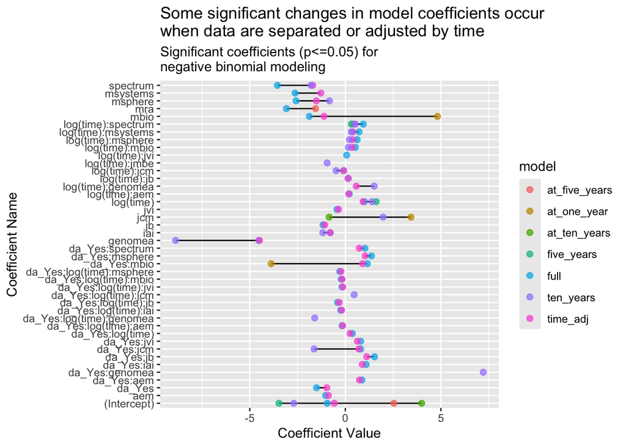

## Does the modeling change when each journal is considered separately?

| names | coefficients | journal | journal pvalue | at one year | at one year pvalue | at five years | at five years pvalue | five years | five years pvalue | at ten years | at ten years pvalue | ten years | ten years pvalue | pretty name |
| --- | --- | --- | --- | --- | --- | --- | --- | --- | --- | --- | --- | --- | --- | --- |
| aac | rsquared | 0.362 |  |  |  |  |  | 0.556 |  | 0.002 |  | 0.476 |  | rsquared |
| aac | (Intercept) | -0.961 | 0.000 |  |  |  |  | -3.442 | 0.000 | 3.995 | 0.000 | -2.696 | 0.000 | (Intercept) |
| aac | da_factorYes | -1.520 | 0.000 |  |  |  |  | -0.189 | 0.743 | -0.075 | 0.863 | -0.267 | 0.448 | da_Yes |
| aac | log(age.in.months) | 0.996 | 0.000 |  |  |  |  | 1.606 | 0.000 |  |  | 1.398 | 0.000 | log(time) |
| aac | da_factorYes:log(age.in.months) | 0.371 | 0.000 |  |  |  |  | 0.069 | 0.664 |  |  | 0.096 | 0.249 | da_Yes:log(time) |
| aac |  |  |  |  |  |  |  |  |  |  |  |  |  |  |
| aem | rsquared | 0.486 |  | 0.014 |  | 0.074 |  | 0.628 |  | 0.022 |  | 0.620 |  | rsquared |
| aem | (Intercept) | -1.965 | 0.000 | 0.000 | 1.000 | 2.737 | 0.000 | -3.528 | 0.000 | 4.041 | 0.000 | -3.225 | 0.000 | (Intercept) |
| aem | da_factorYes | -0.634 | 0.000 | 0.336 | 0.692 | 0.413 | 0.136 | -0.417 | 0.221 | 0.195 | 0.431 | -0.172 | 0.415 | da_Yes |
| aem | log(age.in.months) | 1.196 | 0.000 |  |  |  |  | 1.580 | 0.000 |  |  | 1.499 | 0.000 | log(time) |
| aem | da_factorYes:log(age.in.months) | 0.196 | 0.000 |  |  |  |  | 0.189 | 0.046 |  |  | 0.105 | 0.035 | da_Yes:log(time) |
| genomea | rsquared | 0.064 |  |  |  |  |  |  |  |  |  | 0.032 |  | rsquared |
| genomea | (Intercept) | -5.490 | 0.000 |  |  |  |  |  |  |  |  | -11.523 | 0.000 | (Intercept) |
| genomea | da_factorYes | 0.198 | 0.900 |  |  |  |  |  |  |  |  | 6.910 | 0.025 | da_Yes |
| genomea | log(age.in.months) | 1.574 | 0.000 |  |  |  |  |  |  |  |  | 2.894 | 0.000 | log(time) |
| genomea | da_factorYes:log(age.in.months) | -0.028 | 0.932 |  |  |  |  |  |  |  |  | -1.500 | 0.025 | da_Yes:log(time) |
| genomea |  |  |  |  |  |  |  |  |  |  |  |  |  |  |
| iai | rsquared | 0.390 |  |  |  |  |  | 0.598 |  |  |  | 0.606 |  | rsquared |
| iai | (Intercept) | -1.701 | 0.000 |  |  |  |  | -4.767 | 0.000 |  |  | -3.823 | 0.000 | (Intercept) |
| iai | da_factorYes | -0.405 | 0.204 |  |  |  |  | 0.777 | 0.421 |  |  | 0.608 | 0.255 | da_Yes |
| iai | log(age.in.months) | 1.068 | 0.000 |  |  |  |  | 1.852 | 0.000 |  |  | 1.580 | 0.000 | log(time) |
| iai | da_factorYes:log(age.in.months) | 0.123 | 0.065 |  |  |  |  | -0.151 | 0.574 |  |  | -0.102 | 0.424 | da_Yes:log(time) |
| iai |  |  |  |  |  |  |  |  |  |  |  |  |  |  |
| jb | rsquared | 0.315 |  |  |  |  |  | 0.577 |  |  |  | 0.558 |  | rsquared |
| jb | (Intercept) | -2.115 | 0.000 |  |  |  |  | -3.702 | 0.000 |  |  | -2.867 | 0.000 | (Intercept) |
| jb | da_factorYes | 0.016 | 0.952 |  |  |  |  | 0.634 | 0.341 |  |  | -0.117 | 0.786 | da_Yes |
| jb | log(age.in.months) | 1.150 | 0.000 |  |  |  |  | 1.575 | 0.000 |  |  | 1.322 | 0.000 | log(time) |
| jb | da_factorYes:log(age.in.months) | -0.039 | 0.472 |  |  |  |  | -0.144 | 0.431 |  |  | 0.086 | 0.410 | da_Yes:log(time) |
| jb |  |  |  |  |  |  |  |  |  |  |  |  |  |  |
| jcm | rsquared | 0.188 |  |  |  |  |  | 0.514 |  | 0.027 |  | 0.388 |  | rsquared |
| jcm | (Intercept) | -0.682 | 0.000 |  |  |  |  | -4.309 | 0.000 | 3.148 | 0.000 | -0.789 | 0.009 | (Intercept) |
| jcm | da_factorYes | -0.728 | 0.011 |  |  |  |  | 1.131 | 0.164 | 0.286 | 0.434 | -1.844 | 0.000 | da_Yes |
| jcm | log(age.in.months) | 0.902 | 0.000 |  |  |  |  | 1.969 | 0.000 |  |  | 0.933 | 0.000 | log(time) |
| jcm | da_factorYes:log(age.in.months) | 0.260 | 0.000 |  |  |  |  | -0.314 | 0.170 |  |  | 0.544 | 0.000 | da_Yes:log(time) |
| jcm |  |  |  |  |  |  |  |  |  |  |  |  |  |  |
| jvi | rsquared | 0.417 |  |  |  | 0.024 |  | 0.526 |  | 0.001 |  | 0.517 |  | rsquared |
| jvi | (Intercept) | -1.386 | 0.000 |  |  | 2.506 | 0.000 | -3.666 | 0.000 | 3.933 | 0.000 | -2.494 | 0.000 | (Intercept) |
| jvi | da_factorYes | -0.709 | 0.000 |  |  | -0.170 | 0.560 | -0.291 | 0.531 | 0.080 | 0.879 | -0.613 | 0.028 | da_Yes |
| jvi | log(age.in.months) | 1.063 | 0.000 |  |  |  |  | 1.691 | 0.000 |  |  | 1.345 | 0.000 | log(time) |
| jvi | da_factorYes:log(age.in.months) | 0.194 | 0.000 |  |  |  |  | 0.107 | 0.412 |  |  | 0.193 | 0.005 | da_Yes:log(time) |
| jvi |  |  |  |  |  |  |  |  |  |  |  |  |  |  |
| mbio | rsquared | 0.668 |  | 0.366 |  |  |  | 0.644 |  |  |  | 0.663 |  | rsquared |
| mbio | (Intercept) | -2.811 | 0.000 | 2.485 | 0.000 |  |  | -3.465 | 0.000 |  |  | -2.955 | 0.000 | (Intercept) |
| mbio | da_factorYes | -0.360 | 0.072 | -1.951 | 0.001 |  |  | -0.409 | 0.209 |  |  | -0.418 | 0.060 | da_Yes |
| mbio | log(age.in.months) | 1.516 | 0.000 |  |  |  |  | 1.714 | 0.000 |  |  | 1.557 | 0.000 | log(time) |
| mbio | da_factorYes:log(age.in.months) | 0.154 | 0.002 |  |  |  |  | 0.175 | 0.060 |  |  | 0.172 | 0.002 | da_Yes:log(time) |
| mbio |  |  |  |  |  |  |  |  |  |  |  |  |  |  |
| mra | rsquared | 0.371 |  |  |  |  |  | 0.368 |  |  |  | 0.371 |  | rsquared |
| mra | (Intercept) | -4.050 | 0.005 |  |  |  |  | -3.600 | 0.034 |  |  | -4.050 | 0.005 | (Intercept) |
| mra | da_factorYes | -0.891 | 0.540 |  |  |  |  | -1.830 | 0.283 |  |  | -0.891 | 0.540 | da_Yes |
| mra | log(age.in.months) | 1.391 | 0.000 |  |  |  |  | 1.238 | 0.010 |  |  | 1.391 | 0.000 | log(time) |
| mra | da_factorYes:log(age.in.months) | 0.123 | 0.740 |  |  |  |  | 0.427 | 0.376 |  |  | 0.123 | 0.740 | da_Yes:log(time) |
| mra |  |  |  |  |  |  |  |  |  |  |  |  |  |  |
| msphere | rsquared | 0.652 |  | 0.038 |  |  |  | 0.651 |  |  |  | 0.652 |  | rsquared |
| msphere | (Intercept) | -3.523 | 0.000 | 0.000 | 1.000 |  |  | -3.700 | 0.000 |  |  | -3.523 | 0.000 | (Intercept) |
| msphere | da_factorYes | -0.106 | 0.776 | 0.405 | 0.492 |  |  | -0.268 | 0.585 |  |  | -0.106 | 0.776 | da_Yes |
| msphere | log(age.in.months) | 1.615 | 0.000 |  |  |  |  | 1.679 | 0.000 |  |  | 1.615 | 0.000 | log(time) |
| msphere | da_factorYes:log(age.in.months) | 0.066 | 0.485 |  |  |  |  | 0.109 | 0.427 |  |  | 0.066 | 0.485 | da_Yes:log(time) |
| msphere |  |  |  |  |  |  |  |  |  |  |  |  |  |  |
| msystems | rsquared | 0.717 |  | 0.200 |  |  |  | 0.696 |  |  |  | 0.717 |  | rsquared |
| msystems | (Intercept) | -3.558 | 0.000 | -1.099 | 0.301 |  |  | -3.473 | 0.000 |  |  | -3.558 | 0.000 | (Intercept) |
| msystems | da_factorYes | -0.622 | 0.110 | 1.929 | 0.075 |  |  | -0.854 | 0.060 |  |  | -0.622 | 0.110 | da_Yes |
| msystems | log(age.in.months) | 1.707 | 0.000 |  |  |  |  | 1.679 | 0.000 |  |  | 1.707 | 0.000 | log(time) |
| msystems | da_factorYes:log(age.in.months) | 0.204 | 0.048 |  |  |  |  | 0.281 | 0.031 |  |  | 0.204 | 0.048 | da_Yes:log(time) |
| msystems |  |  |  |  |  |  |  |  |  |  |  |  |  |  |
| spectrum | rsquared | 0.542 |  | 0.022 |  |  |  | 0.542 |  |  |  | 0.542 |  | rsquared |
| spectrum | (Intercept) | -4.461 | 0.000 | 0.025 | 0.907 |  |  | -4.461 | 0.000 |  |  | -4.461 | 0.000 | (Intercept) |
| spectrum | da_factorYes | -0.480 | 0.104 | 0.404 | 0.105 |  |  | -0.480 | 0.104 |  |  | -0.480 | 0.104 | da_Yes |
| spectrum | log(age.in.months) | 1.919 | 0.000 |  |  |  |  | 1.919 | 0.000 |  |  | 1.919 | 0.000 | log(time) |
| spectrum | da_factorYes:log(age.in.months) | 0.214 | 0.021 |  |  |  |  | 0.214 | 0.021 |  |  | 0.214 | 0.021 | da_Yes:log(time) |
| spectrum |  |  |  |  |  |  |  |  |  |  |  |  |  |  |

## Journal model fit with all data from all journals using by Cragg-Uhler pseduo R-squared metric

| names | coefficients | journal |
| --- | --- | --- |
| aac | rsquared | 0.3623 |
| aem | rsquared | 0.4862 |
| genomea | rsquared | 0.0636 |
| iai | rsquared | 0.3896 |
| jb | rsquared | 0.3152 |
| jcm | rsquared | 0.1882 |
| jvi | rsquared | 0.4172 |
| mbio | rsquared | 0.6680 |
| mra | rsquared | 0.3712 |
| msphere | rsquared | 0.6523 |
| msystems | rsquared | 0.7168 |
| spectrum | rsquared | 0.5425 |

- **Overall model fit for data from EACH journal individually:**
  - 4/12 journals have **overall model fit** with R^2 > 0.5

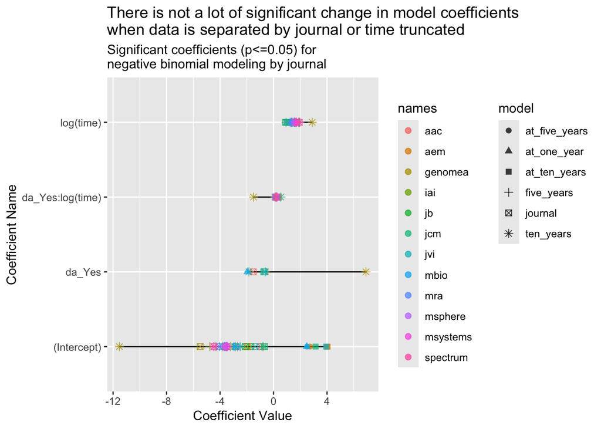

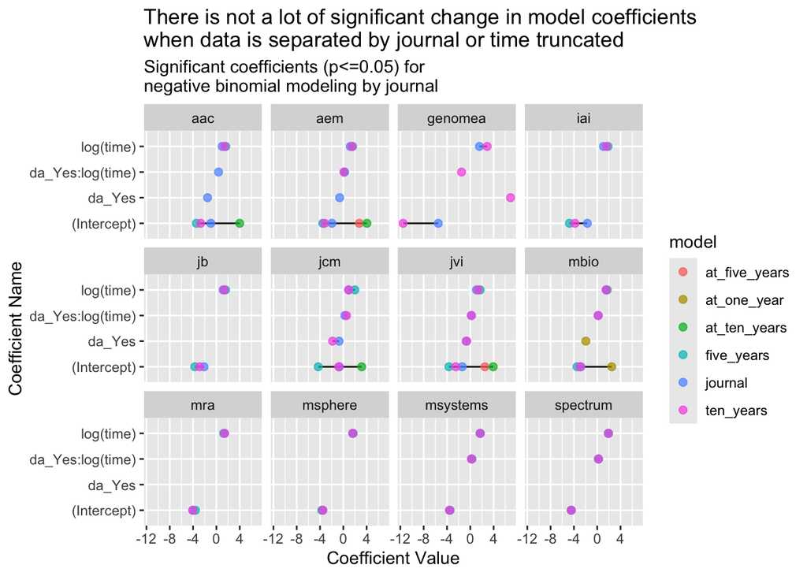

## What about only siginificant data?

- Data looks resistant to truncation of time within a journal, with the intercept being the least resistant to changes.
- Genome Announcements appears to pull coefficient values to the extremes.

Where do we go from here?